# DIVISION DEL DATASET

En este Notebook se muestran algunos de los mecanismos mas utilizados para la division del DAtaSet

## Descripcion

ISCX NSL-KDD dataset 2009

We apologize, this dataset is no longer available.

ISCX NSL-KDD is a data set suggested to solve some of the inherent problems of the KDD'99 data set which are mentioned in [1]. Although, this new version of the KDD data set still suffers from some of the problems discussed by McHugh and may not be a perfect representative of existing real networks, because of the lack of public data sets for network-based IDSs, we believe it still can be applied as an effective benchmark data set to help researchers compare different intrusion detection methods.

Furthermore, the number of records in the NSL-KDD train and test sets are reasonable. This advantage makes it affordable to run the experiments on the complete set without the need to randomly select a small portion. Consequently, evaluation results of different research work will be consistent and comparable.

## Data files

- KDDTrain+.ARFF: The full NSL-KDD train set with binary labels in ARFF format
- KDDTrain+.TXT: The full NSL-KDD train set including attack-type labels and difficulty level in CSV format
- KDDTrain+_20Percent.ARFF: A 20% subset of the KDDTrain+.arff file
- KDDTrain+_20Percent.TXT: A 20% subset of the KDDTrain+.txt file
- KDDTest+.ARFF: The full NSL-KDD test set with binary labels in ARFF format
- KDDTest+.TXT: The full NSL-KDD test set including attack-type labels and difficulty level in CSV format
- KDDTest-21.ARFF: A subset of the KDDTest+.arff file which does not include records with difficulty level of 21 out of 21
- KDDTest-21.TXT: A subset of the KDDTest+.txt file which does not include records with difficulty level of 21 out of 21 Improvements to the KDD'99 dataset

The ISCX NSL-KDD data set has the following advantages over the original KDD data set:

It does not include redundant records in the train set, so the classifiers will not be biased towards more frequent records. There is no duplicate records in the proposed test sets; therefore, the performance of the learners are not biased by the methods which have better detection rates on the frequent records. The number of selected records from each difficultylevel group is inversely proportional to the percentage of records in the original KDD data set. As a result, the classification rates of distinct machine learning methods vary in a wider range, which makes it more efficient to have an accurate evaluation of different learning techniques. The number of records in the train and test sets are reasonable, which makes it affordable to run the experiments on the complete set without the need to randomly select a small portion. Consequently, evaluation results of different research works will be consistent and comparable. Statistical observations

One of the most important deficiencies in the KDD data set is the huge number of redundant records, which causes the learning algorithms to be biased towards the frequent records, and thus prevent them from learning unfrequent records which are usually more harmful to networks such as U2R and R2L attacks. In addition, the existence of these repeated records in the test set will cause the evaluation results to be biased by the methods which have better detection rates on the frequent records.

In addition, we analyzed the difficulty level of the records in KDD data set. Surprisingly, about 98% of the records in the train set and 86% of the records in the test set were correctly classified with all the 21 learners.

In order to perform our experiments, we randomly created three smaller subsets of the KDD train set each of which included fifty thousand records of information. Each of the learners where trained over the created train sets. We then employed the 21 learned machines (7 learners, each trained 3 times) to label the records of the entire KDD train and test sets, which provides us with 21 predicated labels for each record. Further, we annotated each record of the data set with a #successfulPrediction value, which was initialized to zero. Now, since the KDD data set provides the correct label for each record, we compared the predicated label of each record given by a specific learner with the actual label, where we incremented #successfulPrediction by one if a match was found. Through this process, we calculated the number of learners that were able to correctly label that given record. The highest value for #successfulPrediction is 21, which conveys the fact that all learners were able to correctly predict the label of that record.

Statistics of redundant records in the KDD train set

Original records | Distinct records | Reduction rate

Attacks: 3,925,650 | 262,178 | 93.32% Normal: 972,781 | 812,814 | 16.44% Total: 4,898,431 | 1,074,992 | 78.05% Statistics of redundant records in the KDD test set

Original records | Distinct records | Reduction rate

Attacks: 250,436 | 29,378 | 88.26% Normal: 60,591 | 47,911 | 20.92% Total: 311,027 | 77,289 | 75.15% License

You may redistribute, republish, and mirror the ISCX NSL-KDD dataset in any form. However, any use or redistribution of the data must include a citation to the NSL-KDD dataset and the paper referenced below.

References: [1] M. Tavallaee, E. Bagheri, W. Lu, and A. Ghorbani, “A Detailed Analysis of the KDD CUP 99 Data Set,” Submitted to Second IEEE Symposium on Computational Intelligence for Security and Defense Applications (CISDA), 2009. [URL] (https://www-unb-ca.translate.goog/cic/datasets/nsl.html?_x_tr_sl=en&_x_tr_tl=es&_x_tr_hl=es&_x_tr_pto=tc)

## 1.- Lectura del DataSet

```
<class 'pandas.core.frame.DataFrame'>
RangeIndex: 125973 entries, 0 to 125972
Data columns (total 42 columns):
 #   Column                       Non-Null Count   Dtype
---  ------                       --------------   -----
 0   duration                     125973 non-null  float64
 1   protocol_type                125973 non-null  object
 2   service                      125973 non-null  object
 3   flag                         125973 non-null  object
 4   src_bytes                    125973 non-null  float64
 5   dst_bytes                    125973 non-null  float64
 6   land                         125973 non-null  object
 7   wrong_fragment               125973 non-null  float64
 8   urgent                       125973 non-null  float64
 9   hot                          125973 non-null  float64
```

[output cut: 34 more lines]

## 2.- Division del DataSet

Se debe separar el DataSEt en los diferentes subconjuntos necesarios para realzar los procesos de entrenamiento, validacion y pruebas. Sklearn implemneta la funcion **train_test_split**.

```
<class 'pandas.core.frame.DataFrame'>
Index: 75583 entries, 98320 to 121958
Data columns (total 42 columns):
 #   Column                       Non-Null Count  Dtype
---  ------                       --------------  -----
 0   duration                     75583 non-null  float64
 1   protocol_type                75583 non-null  object
 2   service                      75583 non-null  object
 3   flag                         75583 non-null  object
 4   src_bytes                    75583 non-null  float64
 5   dst_bytes                    75583 non-null  float64
 6   land                         75583 non-null  object
 7   wrong_fragment               75583 non-null  float64
 8   urgent                       75583 non-null  float64
 9   hot                          75583 non-null  float64
```

[output cut: 34 more lines]

```
Longitud del Training Set: 75583
Longitud del Validacion Set: 25195
Longitud del Train Set: 25195
```

### 3.- Particionado Aleatorio y Stratified Sampling.

Sklearn implementa la funcion **train_test_split**, sin embargo esta funcion realiza un particioando del DataSet Aleatorio para cada vez que se ejecuta el script. A un añadiendo una semilla fija y aleatoria, cada vez que se cargue de nuevo en DataSet se generan nuevos subconjuntos. Esto pude ocasionar que despues de muchos intentos el algoritmo "vea" todo el DataSet.

Para solucionar este problema Sklearn a introducido el parametro **Shuffle** en la funcion **train_test_split**.

```
Estos metodos para dividir el DataSet estan bien si se tienes un conjunto de Datos muy grande, pero si no se tiene se corre el riesgo de introducir **Sampling Bias**.

Para evitar esto se utiliza un metodo de Sampling que se llamaa **Stratified Sampling**. La poblacion dividida en subconjuntos homogeneos llamados **strata**. El objetivo es que no quede ninguna caracteristica del DataSet sin representacion en ninguno de los conjuntos de datos para una o mas caracteristicas en particular.

Sklearn introduce el parametro **Stratify** en la funcion **train_test_split** para controlar este comportamiento.
```

*This stratofy parameter makes a spolit so that the proportion of values in the sample produced will be tah same as the propotion of values provided to parmeter stratify.*

*For example, if variable "y" is binary categorical variable with value 0 and 1 and there are 25% of zeros and 75% of ones, stratify = y will make sure that your random split has 25% of 0's and 75% of 1's.*

https://stackoverflow.com/questions

## 4.- Generacion de una funcion de particionado

```
Longitud del DataSet: 125973
```

```
Longitud del Training Set: 75583
Longitud del Validacion Set: 25195
Longitud del Train Set: 25195
```

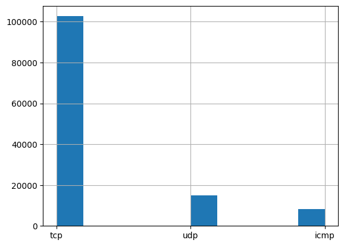

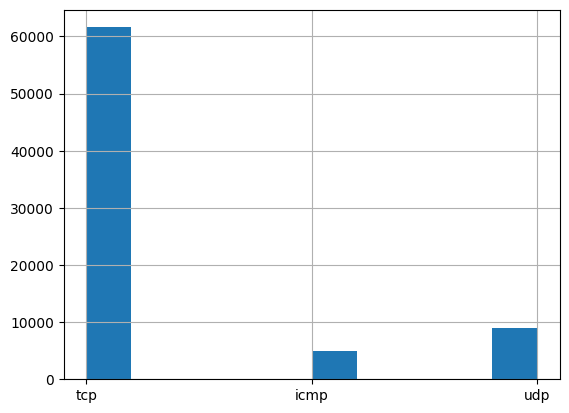

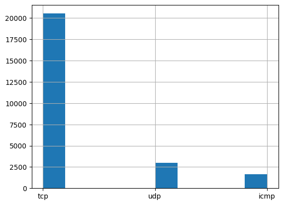

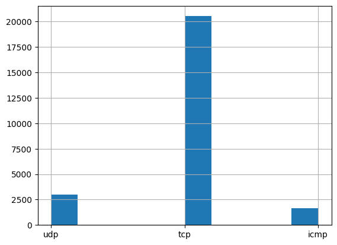